# Extracting and Visualizing Stock Data

## Description

Extracting essential data from a dataset and displaying it is a necessary part of data science; therefore individuals can make correct decisions based on the data. In this assignment, you will extract some stock data, you will then display this data in a graph.

## Table of Contents

- Define a Function that Makes a Graph
- Question 1: Use yfinance to Extract Stock Data
- Question 2: Use Webscraping to Extract Tesla Revenue Data
- Question 3: Use yfinance to Extract Stock Data
- Question 4: Use Webscraping to Extract GME Revenue Data
- Question 5: Plot Tesla Stock Graph
- Question 6: Plot GameStop Stock Graph

Estimated Time Needed: **30 min**

***Note***:- If you are working in IBM Cloud Watson Studio, please replace the command for installing nbformat from `!pip install nbformat==4.2.0` to simply `!pip install nbformat`

```python
!pip install yfinance==0.1.67
!mamba install bs4==4.10.0 -y
!pip install nbformat==4.2.0
```

```
zsh:1: command not found: mamba
```

```python
import yfinance as yf
import pandas as pd
import requests
from bs4 import BeautifulSoup
import plotly.graph_objects as go
from plotly.subplots import make_subplots
```

In Python, you can ignore warnings using the warnings module. You can use the filterwarnings function to filter or ignore specific warning messages or categories.

```python
import warnings
# Ignore all warnings
warnings.filterwarnings("ignore", category=FutureWarning)
```

## Define Graphing Function

In this section, we define the function `make_graph`. You don't have to know how the function works, you should only care about the inputs. It takes a dataframe with stock data (dataframe must contain Date and Close columns), a dataframe with revenue data (dataframe must contain Date and Revenue columns), and the name of the stock.

```python
def make_graph(stock_data, revenue_data, stock):
    fig = make_subplots(rows=2, cols=1, shared_xaxes=True, subplot_titles=("Historical Share Price", "Historical Revenue"), vertical_spacing=.3)

    # Filter data
    stock_data_specific = stock_data[stock_data['Date'] <= '2021-06-14']
    revenue_data_specific = revenue_data[revenue_data['Date'] <= '2021-04-30']

    # Plotting stock data
    fig.add_trace(go.Scatter(
        x=pd.to_datetime(stock_data_specific['Date']),  # Convert to datetime
        y=stock_data_specific['close'].astype("float"),
        name="Share Price"),
        row=1, col=1
    )

    # Plotting revenue data
    fig.add_trace(go.Scatter(
        x=pd.to_datetime(revenue_data_specific['Date']),  # Convert to datetime
        y=revenue_data_specific['Revenue'].astype("float"),
        name="Revenue"),
        row=2, col=1
    )

    # Update axes and layout
    fig.update_xaxes(title_text="Date", row=1, col=1)
    fig.update_xaxes(title_text="Date", row=2, col=1)
    fig.update_yaxes(title_text="Price ($US)", row=1, col=1)
    fig.update_yaxes(title_text="Revenue ($US Millions)", row=2, col=1)
    fig.update_layout(showlegend=False, height=900, title=stock, xaxis_rangeslider_visible=True)


    fig.show()
```

## Question 1: Use yfinance to Extract Stock Data

# PEER GRADER: PLEASE NOTE YFINANCE HAS A BUG, NEEDED TO USE ALTERNATIVE API/CODE

Using the `Ticker` function enter the ticker symbol of the stock we want to extract data on to create a ticker object. The stock is Tesla and its ticker symbol is `TSLA`.

```python
import yfinance as yf
tesla = yf.Ticker("TSLA")
```

Using the ticker object and the function `history` extract stock information and save it in a dataframe named `tesla_data`. Set the `period` parameter to `max` so we get information for the maximum amount of time.

```python
import pandas_datareader.data as web
from datetime import datetime

# Define the start date for fetching data
start = datetime(2010, 1, 1)

# Alpha Vantage API Key
api_key = 'DELETED FOR SECURITY/PRIVACY'

# Fetching data using Alpha Vantage
tesla_data = web.DataReader("TSLA", "av-daily", start=start, end=datetime.now(), api_key=api_key)

# Ensure the index is a DateTimeIndex
tesla_data.index = pd.to_datetime(tesla_data.index)

# If the date is in the index and you want to move it to a column
tesla_data.reset_index(inplace=True)
tesla_data.rename(columns={'index': 'Date'}, inplace=True)

# Check and manage timezone if necessary for the 'Date' column
if tesla_data['Date'].dt.tz is None:
    tesla_data['Date'] = tesla_data['Date'].dt.tz_localize('UTC')
```

**Reset the index** using the `reset_index(inplace=True)` function on the tesla_data DataFrame and display the first five rows of the `tesla_data` dataframe using the `head` function. Take a screenshot of the results and code from the beginning of Question 1 to the results below.

```python
# Reset the index of the DataFrame
tesla_data.reset_index(inplace=True)

# Display the first five rows of the DataFrame
print(tesla_data.head())
```

```
   index                      Date   open     high    low  close    volume
0      0 2010-06-29 00:00:00+00:00  19.00  25.0000  17.54  23.89  18766300
1      1 2010-06-30 00:00:00+00:00  25.79  30.4192  23.30  23.83  17187100
2      2 2010-07-01 00:00:00+00:00  25.00  25.9200  20.27  21.96   8218800
3      3 2010-07-02 00:00:00+00:00  23.00  23.1000  18.71  19.20   5139800
4      4 2010-07-06 00:00:00+00:00  20.00  20.0000  15.83  16.11   6866900
```

## Question 2: Use Webscraping to Extract Tesla Revenue Data

Use the `requests` library to download the webpage https://cf-courses-data.s3.us.cloud-object-storage.appdomain.cloud/IBMDeveloperSkillsNetwork-PY0220EN-SkillsNetwork/labs/project/revenue.htm Save the text of the response as a variable named `html_data`.

```python
import requests
url = 'https://cf-courses-data.s3.us.cloud-object-storage.appdomain.cloud/IBMDeveloperSkillsNetwork-PY0220EN-SkillsNetwork/labs/project/revenue.htm'

# Send a GET request to the URL
response = requests.get(url)

# Save the text of the response
html_data = response.text
```

Parse the html data using `beautiful_soup`.

```python
from bs4 import BeautifulSoup

# Create a Beautiful Soup object from the HTML data
soup = BeautifulSoup(html_data, 'lxml')

# Print out the soup object to see the parsed HTML
print(soup.prettify()[:1000])  # Print the first 1000 characters of the prettified HTML
```

[output not shown]

Using `BeautifulSoup` or the `read_html` function extract the table with `Tesla Revenue` and store it into a dataframe named `tesla_revenue`. The dataframe should have columns `Date` and `Revenue`.

**Click here if you need help locating the table**

```
Below is the code to isolate the table, you will now need to loop through the rows and columns like in the previous lab

soup.find_all("tbody")[1]

If you want to use the read_html function the table is located at index 1

We are focusing on quarterly revenue in the lab.
```

```python
# Use read_html to automatically parse the HTML and extract tables
dfs = pd.read_html(html_data)

# Assuming the Tesla Revenue table is the first table extracted
tesla_revenue = dfs[0]

# Renaming columns to 'Date' and 'Revenue' if they are not already named
tesla_revenue.columns = ['Date', 'Revenue']

# Display the DataFrame
print(tesla_revenue.head())
```

```
   Date  Revenue
0  2021  $53,823
1  2020  $31,536
2  2019  $24,578
3  2018  $21,461
4  2017  $11,759
```

```python
tesla_revenue["Revenue"] = tesla_revenue['Revenue'].str.replace(',|\$',"")
```

Execute the following lines to remove an null or empty strings in the Revenue column.

```python
tesla_revenue.dropna(inplace=True)

tesla_revenue = tesla_revenue[tesla_revenue['Revenue'] != ""]
```

Display the last 5 row of the `tesla_revenue` dataframe using the `tail` function. Take a screenshot of the results.

```python
# Display the last five rows of the 'tesla_revenue' DataFrame
print(tesla_revenue.tail())
```

```
    Date Revenue
8   2013  $2,013
9   2012    $413
10  2011    $204
11  2010    $117
12  2009    $112
```

## Question 3: Use yfinance to Extract Stock Data

# PEER GRADER: PLEASE NOTE YFINANCE HAS A BUG, NEEDED TO USE ALTERNATIVE API/CODE

Using the `Ticker` function enter the ticker symbol of the stock we want to extract data on to create a ticker object. The stock is GameStop and its ticker symbol is `GME`.

```python
import yfinance as yf
tesla = yf.Ticker("GME")
```

Using the ticker object and the function `history` extract stock information and save it in a dataframe named `gme_data`. Set the `period` parameter to `max` so we get information for the maximum amount of time.

```python
# Define the start date for fetching data
start = datetime(2010, 1, 1)

# Alpha Vantage API Key
api_key = 'EBT0V43ZLPM8NPPB'

# Fetching data using Alpha Vantage
gme_data = web.DataReader("GME", "av-daily", start=start, end=datetime.now(), api_key=api_key)

# Ensure the index is a DateTimeIndex
gme_data.index = pd.to_datetime(gme_data.index)

# Check and manage timezone if necessary
if gme_data.index.tz is None:
    gme_data.index = gme_data.index.tz_localize('UTC')
```

**Reset the index** using the `reset_index(inplace=True)` function on the gme_data DataFrame and display the first five rows of the `gme_data` dataframe using the `head` function. Take a screenshot of the results and code from the beginning of Question 3 to the results below.

```python
# Reset the index of the DataFrame
gme_data.reset_index(inplace=True)

# Display the first five rows of the DataFrame
print(gme_data.head())
```

```
                      index   open   high    low  close    volume
0 2010-01-04 00:00:00+00:00  22.07  22.95  22.00  22.90   6675700
1 2010-01-05 00:00:00+00:00  22.91  23.74  22.90  23.52   5317400
2 2010-01-06 00:00:00+00:00  23.46  24.10  23.22  24.03   5367800
3 2010-01-07 00:00:00+00:00  20.01  21.17  19.42  20.46  41190300
4 2010-01-08 00:00:00+00:00  20.64  21.23  20.23  20.29  11968100
```

## Question 4: Use Webscraping to Extract GME Revenue Data

Use the `requests` library to download the webpage https://cf-courses-data.s3.us.cloud-object-storage.appdomain.cloud/IBMDeveloperSkillsNetwork-PY0220EN-SkillsNetwork/labs/project/stock.html. Save the text of the response as a variable named `html_data`.

```python
url= 'https://cf-courses-data.s3.us.cloud-object-storage.appdomain.cloud/IBMDeveloperSkillsNetwork-PY0220EN-SkillsNetwork/labs/project/stock.html'
# Send a GET request to the URL
response = requests.get(url)

# Save the text of the response
html_data = response.text
```

Parse the html data using `beautiful_soup`.

```python
from bs4 import BeautifulSoup

# Create a Beautiful Soup object from the HTML data
soup = BeautifulSoup(html_data, 'lxml')

# Print out the soup object to see the parsed HTML
print(soup.prettify()[:1000])  # Print the first 1000 characters of the prettified HTML
```

[output not shown]

Using `BeautifulSoup` or the `read_html` function extract the table with `GameStop Revenue` and store it into a dataframe named `gme_revenue`. The dataframe should have columns `Date` and `Revenue`. Make sure the comma and dollar sign is removed from the `Revenue` column using a method similar to what you did in Question 2.

**Click here if you need help locating the table**

```
Below is the code to isolate the table, you will now need to loop through the rows and columns like in the previous lab

soup.find_all("tbody")[1]

If you want to use the read_html function the table is located at index 1
```

```python
# Use read_html to automatically parse the HTML and extract tables
dfs = pd.read_html(html_data)

# Assuming the Tesla Revenue table is the first table extracted
gme_revenue = dfs[0]

# Renaming columns to 'Date' and 'Revenue' if they are not already named
gme_revenue.columns = ['Date', 'Revenue']

# Display the DataFrame
print(gme_revenue.head())
```

```
   Date Revenue
0  2020  $6,466
1  2019  $8,285
2  2018  $8,547
3  2017  $7,965
4  2016  $9,364
```

Display the last five rows of the `gme_revenue` dataframe using the `tail` function. Take a screenshot of the results.

```python
print(gme_revenue.tail())
```

```
    Date Revenue
11  2009  $8,806
12  2008  $7,094
13  2007  $5,319
14  2006  $3,092
15  2005  $1,843
```

## Question 5: Plot Tesla Stock Graph

```python
# Convert the 'Date' column in tesla_revenue from integer year to datetime format
tesla_revenue['Date'] = pd.to_datetime(tesla_revenue['Date'].astype(str) + '-01-01')

# Ensure the 'Revenue' column is in a numeric format, stripping any commas and converting to integer
tesla_revenue['Revenue'] = tesla_revenue['Revenue'].replace('[\$,]', '', regex=True).astype(int)
```

```python
import matplotlib.pyplot as plt
import numpy as np

def tesla_graph(tesla_data, tesla_revenue, title):
    fig, ax1 = plt.subplots(figsize=(14, 8))

    # Convert series to numpy arrays explicitly to avoid multi-dimensional indexing issues
    dates = tesla_data['Date'].values  # Use .values to ensure numpy array
    closes = tesla_data['close'].values  # Use .values to ensure numpy array

    color = 'tab:red'
    ax1.set_xlabel('Date')
    ax1.set_ylabel('tesla price', color=color)
    ax1.plot(dates, closes, color=color, label='tesla Price')
    ax1.tick_params(axis='y', labelcolor=color)
    ax1.legend(loc='upper left')

    ax2 = ax1.twinx()
    color = 'tab:blue'
    ax2.set_ylabel('Revenue', color=color)

    # Ensure data is in numpy array form for 'Revenue'
    revenue_dates = tesla_revenue['Date'].values  # Convert to numpy array
    revenues = tesla_revenue['Revenue'].values  # Convert to numpy array

    ax2.plot(revenue_dates, revenues, color=color, marker='o', linestyle='-', label='Revenue')
    ax2.tick_params(axis='y', labelcolor=color)
    ax2.legend(loc='upper right')

    plt.title(title)
    plt.show()
```

```python
print (tesla_data.head())
```

```
   index                      Date   open     high    low  close    volume
0      0 2010-06-29 00:00:00+00:00  19.00  25.0000  17.54  23.89  18766300
1      1 2010-06-30 00:00:00+00:00  25.79  30.4192  23.30  23.83  17187100
2      2 2010-07-01 00:00:00+00:00  25.00  25.9200  20.27  21.96   8218800
3      3 2010-07-02 00:00:00+00:00  23.00  23.1000  18.71  19.20   5139800
4      4 2010-07-06 00:00:00+00:00  20.00  20.0000  15.83  16.11   6866900
```

```python
print(tesla_revenue.head())
```

```
        Date  Revenue
0 2021-01-01    53823
1 2020-01-01    31536
2 2019-01-01    24578
3 2018-01-01    21461
4 2017-01-01    11759
```

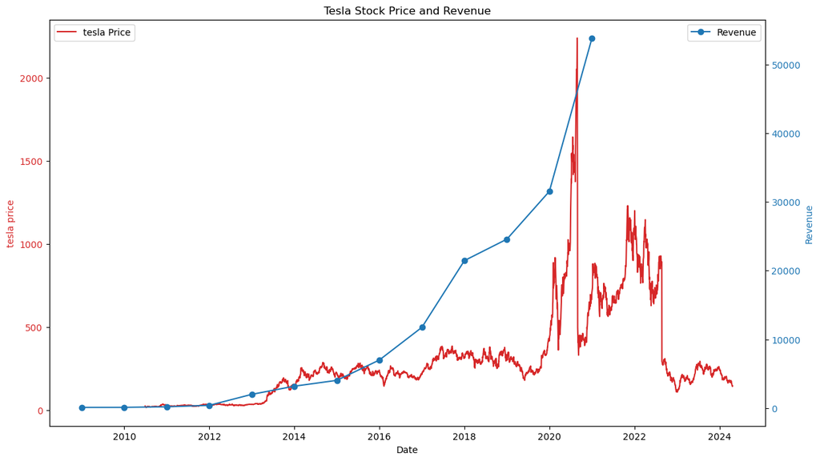

```python
tesla_graph(tesla_data, tesla_revenue, 'Tesla Stock Price and Revenue')
```

## Question 6: Plot GameStop Stock Graph

Use the `make_graph` function to graph the GameStop Stock Data, also provide a title for the graph. The structure to call the `make_graph` function is `make_graph(gme_data, gme_revenue, 'GameStop')`. Note the graph will only show data upto June 2021.

```python
# Convert the 'Date' column in tesla_revenue from integer year to datetime format
gme_revenue['Date'] = pd.to_datetime(gme_revenue['Date'].astype(str) + '-01-01')

# Ensure the 'Revenue' column is in a numeric format, stripping any commas and converting to integer
gme_revenue['Revenue'] = gme_revenue['Revenue'].replace('[\$,]', '', regex=True).astype(int)
```

```python
# Rename the 'index' column to 'Date'
gme_data.rename(columns={'index': 'Date'}, inplace=True)
print (gme_data.head())
```

```
                       Date   open   high    low  close    volume
0 2010-01-04 00:00:00+00:00  22.07  22.95  22.00  22.90   6675700
1 2010-01-05 00:00:00+00:00  22.91  23.74  22.90  23.52   5317400
2 2010-01-06 00:00:00+00:00  23.46  24.10  23.22  24.03   5367800
3 2010-01-07 00:00:00+00:00  20.01  21.17  19.42  20.46  41190300
4 2010-01-08 00:00:00+00:00  20.64  21.23  20.23  20.29  11968100
```

```python
print (gme_revenue.head())
```

```
        Date  Revenue
0 2020-01-01     6466
1 2019-01-01     8285
2 2018-01-01     8547
3 2017-01-01     7965
4 2016-01-01     9364
```

```python
make_graph(gme_data, gme_revenue, 'GameStop Stock Price and Revenue')
```

[interactive chart not shown]

```python
print(gme_data.columns)
```

```
Index(['Date', 'open', 'high', 'low', 'close', 'volume'], dtype='object')
```

## About the Authors:

[Joseph Santarcangelo](https://www.linkedin.com/in/joseph-s-50398b136/) has a PhD in Electrical Engineering, his research focused on using machine learning, signal processing, and computer vision to determine how videos impact human cognition. Joseph has been working for IBM since he completed his PhD.

Azim Hirjani

## Change Log

| Date (YYYY-MM-DD) | Version | Changed By | Change Description |
| --- | --- | --- | --- |
| 2022-02-28 | 1.2 | Lakshmi Holla | Changed the URL of GameStop |
| 2020-11-10 | 1.1 | Malika Singla | Deleted the Optional part |
| 2020-08-27 | 1.0 | Malika Singla | Added lab to GitLab |